# Exp8_MLM report

Mrudula & Carina

31 May,2021

**This report highlights the results from the Multi level analysis for Experiment 8.** Data from experiment 8 has already been prepared with the relevant factors such as :

1. Distance: How far ago was the last occurence
2. Distance_type: Was the last occurence a SingleD or a MultipleD trial. If it is MultipleD then Distance_type is 1 and if it is SingleD then it is 2
3. ResponseRel: Whether the previous response was repeated or changed.
4. Validity and Saliency factors were converted to numeric: Valid trials are 1, and invalid and -1 similarly Salient is 1 and nonsalient is -1

The prepared dataset is saved as *Exp8_DataforMLM.csv* and is loaded to perform the MLM.

### Data Preparation and cleaning

This data is further edited to be prepared for analysis in the following ways

1. Create numeric factor for Previous Response : RR (1) and RC(2)
2. Removing compund trials and choosing only SingleD trials that were used for analysis
3. Centering predictors : within participants as level 1 predictors are participants. This is done using the formula $cwp = Actual value - mean$
   - Previous Response_cwp
   - Distance_cwp
   - Distance_Type_cwp

These are then merged with the main dataframe

# Multi Level Analysis

## 1. Model1 - similar to ANOVA data

This model replicates the ANOVa on the aggregated data used in the standard analysis. The factors used are:

- Validity: valid (1) and invalid(-1)
- Saliency: Salient(1) and nonsalient(-1)
- Val*Sal interaction: indicating overshadowing if validity effect is larger for salient vs nonsalient trials

### 1. with RTs as dependant variable

```r
randomSlopes_m1<-lmer(RT_io~1+val*sal + (1+val*sal|participant),
                      data=raw.data,
                      REML=F,
                      na.action = "na.omit")


tab_model(randomSlopes_m1, show.se = TRUE,show.stat = TRUE, show.ci = FALSE,show.aic = TRUE, show.loglik = TRUE,
                  dv.labels = "Reaction Time")
```

|  | Reaction Time |  |  |  |
| --- | --- | --- | --- | --- |
| Predictors | Estimates | std. Error | Statistic | p |
| (Intercept) | 565.34 | 8.93 | 63.30 | **<0.001** |
| val | -0.74 | 2.26 | -0.33 | 0.744 |
| sal | -2.85 | 1.78 | -1.60 | 0.109 |
| val * sal | -4.12 | 2.22 | -1.86 | 0.063 |
| Random Effects |  |  |  |  |
| σ<sup>2</sup> | 13318.57 |  |  |  |
| τ<sub>00</sub> <sub>participant</sub> | 5136.96 |  |  |  |
| τ<sub>11</sub> <sub>participant.val</sub> | 134.65 |  |  |  |
| τ<sub>11</sub> <sub>participant.sal</sub> | 3.92 |  |  |  |
| τ<sub>11</sub> <sub>participant.val:sal</sub> | 122.52 |  |  |  |
| ρ<sub>01</sub> | 0.46 |  |  |  |
|  | -0.57 |  |  |  |
|  | 0.23 |  |  |  |
| N <sub>participant</sub> | 67 |  |  |  |
| Observations | 11994 |  |  |  |
| Marginal R<sup>2</sup> / Conditional R<sup>2</sup> | 0.003 / NA |  |  |  |
| AIC | 148347.303 |  |  |  |
| log-Likelihood | -74158.651 |  |  |  |

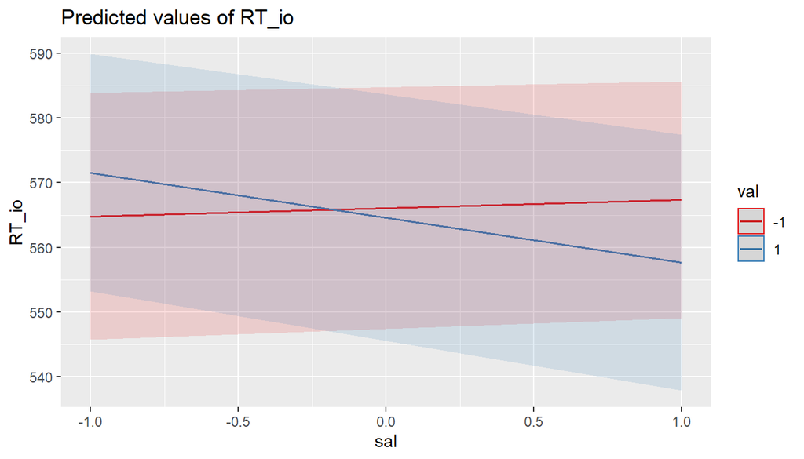

```r
plot_model(randomSlopes_m1, type = "pred", terms = c("sal", "val[minmax]"))
```

```r
summary(randomSlopes_m1)
```

```
## Linear mixed model fit by maximum likelihood . t-tests use Satterthwaite's
##   method [lmerModLmerTest]
## Formula: RT_io ~ 1 + val * sal + (1 + val * sal | participant)
##    Data: raw.data
##
##      AIC      BIC   logLik deviance df.resid
## 148347.3 148458.2 -74158.7 148317.3    11979
##
## Scaled residuals:
##     Min      1Q  Median      3Q     Max
## -3.9643 -0.6430 -0.1117  0.5162  6.0342
##
## Random effects:
##  Groups      Name        Variance  Std.Dev. Corr
##  participant (Intercept)  5136.961  71.673
##              val           134.654  11.604   0.46
##              sal             3.916   1.979  -0.57  0.47
##              val:sal       122.524  11.069   0.23  0.97  0.67
##  Residual                13318.568 115.406
## Number of obs: 11994, groups:  participant, 67
##
## Fixed effects:
##              Estimate Std. Error        df t value Pr(>|t|)
## (Intercept)  565.3394     8.9315   66.9497  63.297   <2e-16 ***
## val           -0.7384     2.2600   84.4747  -0.327   0.7447
## sal           -2.8463     1.7764 1299.4080  -1.602   0.1093
## val:sal       -4.1211     2.2199   84.1748  -1.856   0.0669 .
## ---
## Signif. codes:  0 '***' 0.001 '**' 0.01 '*' 0.05 '.' 0.1 ' ' 1
##
## Correlation of Fixed Effects:
##         (Intr) val    sal
## val      0.161
## sal     -0.070  0.019
## val:sal  0.133  0.387 -0.573
## convergence code: 0
## boundary (singular) fit: see ?isSingular
```

### 2. with ErrorRates

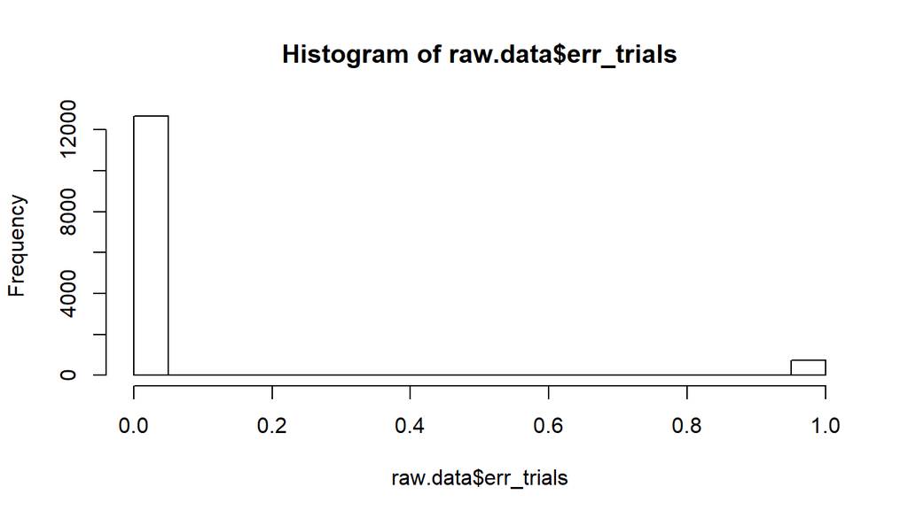

```r
#Error rates

randomSlopes_m1_err<-glmer(err_trials~1+val*sal + (1+val*sal|participant),
                      data=raw.data,
                      na.action = "na.omit", binomial)

randomSlopes_m1_err<-glmer(err_trials~1+val*sal + (1|participant),
                           data=raw.data,
                           na.action = "na.omit", binomial)

hist(raw.data$err_trials)
```

```r
summary(randomSlopes_m1_err)
```

```
## Generalized linear mixed model fit by maximum likelihood (Laplace
##   Approximation) [glmerMod]
##  Family: binomial  ( logit )
## Formula: err_trials ~ 1 + val * sal + (1 | participant)
##    Data: raw.data
##
##      AIC      BIC   logLik deviance df.resid
##   5527.7   5565.2  -2758.8   5517.7    13395
##
## Scaled residuals:
##     Min      1Q  Median      3Q     Max
## -0.5816 -0.2685 -0.2060 -0.1655  8.2307
##
## Random effects:
##  Groups      Name        Variance Std.Dev.
##  participant (Intercept) 0.4735   0.6881
## Number of obs: 13400, groups:  participant, 67
##
## Fixed effects:
##             Estimate Std. Error z value Pr(>|z|)
## (Intercept) -3.00332    0.10923 -27.496  < 2e-16 ***
## val         -0.06769    0.06489  -1.043    0.297
## sal          0.26653    0.06489   4.107 4.00e-05 ***
## val:sal     -0.34338    0.06490  -5.291 1.21e-07 ***
## ---
## Signif. codes:  0 '***' 0.001 '**' 0.01 '*' 0.05 '.' 0.1 ' ' 1
##
## Correlation of Fixed Effects:
##         (Intr) val    sal
## val     -0.477
## sal     -0.249  0.426
## val:sal  0.257 -0.414 -0.806
```

```r
tab_model(randomSlopes_m1_err, show.se = TRUE,show.stat = TRUE, show.ci = FALSE,show.aic = TRUE, show.loglik = TRUE,
                  dv.labels = "Error Rate")
```

|  | Error Rate |  |  |  |
| --- | --- | --- | --- | --- |
| Predictors | Odds Ratios | std. Error | Statistic | p |
| (Intercept) | 0.05 | 0.01 | -27.50 | **<0.001** |
| val | 0.93 | 0.06 | -1.04 | 0.297 |
| sal | 1.31 | 0.08 | 4.11 | **<0.001** |
| val * sal | 0.71 | 0.05 | -5.29 | **<0.001** |
| Random Effects |  |  |  |  |
| σ<sup>2</sup> | 3.29 |  |  |  |
| τ<sub>00</sub> <sub>participant</sub> | 0.47 |  |  |  |
| ICC | 0.13 |  |  |  |
| N <sub>participant</sub> | 67 |  |  |  |
| Observations | 13400 |  |  |  |
| Marginal R<sup>2</sup> / Conditional R<sup>2</sup> | 0.012 / 0.136 |  |  |  |
| AIC | 5527.683 |  |  |  |
| log-Likelihood | -2758.841 |  |  |  |

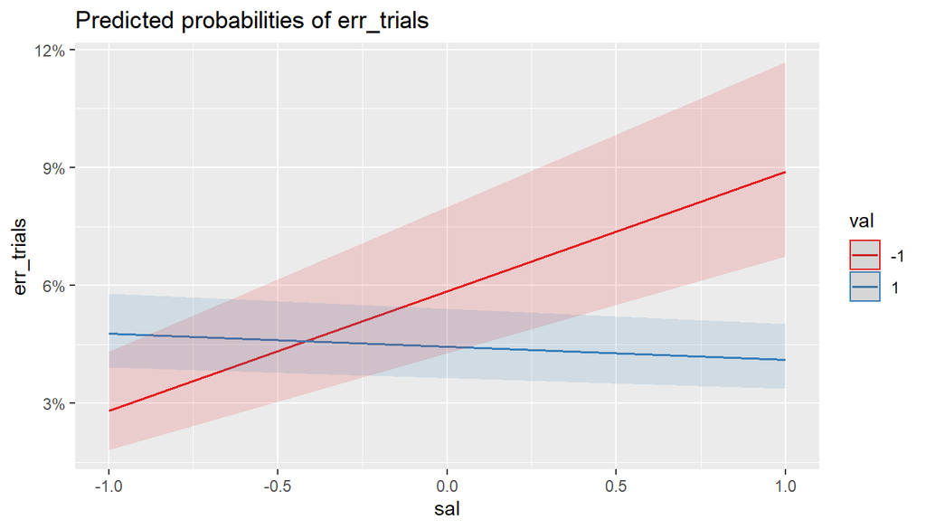

```r
# significant interaction and significant main effect of saliency for both types of randomslopes

plot_model(randomSlopes_m1_err, type = "pred", terms = c("sal", "val[minmax]"))
```

## 2. Model2 : Adding Previous Response, Distance and Distance Type as factors

Will the interaction still survive upon adding these factors? It *almost* does for RT and strongly does for ER

### 1. with RT

```r
randomSlopes_m2<-lmer(RT_io~1+val*sal + previous_rm_cwp+ Distance_cwp + Distance_type_cwp +(1+val*sal + previous_rm_cwp + Distance_cwp + Distance_type_cwp|participant),
                      data=raw.data,
                      REML=F,
                      na.action = "na.omit")
tab_model(randomSlopes_m2, show.se = TRUE,show.stat = TRUE, show.ci = FALSE, show.aic = TRUE, show.loglik = TRUE,
                  dv.labels = "Reaction Time")
```

|  | Reaction Time |  |  |  |
| --- | --- | --- | --- | --- |
| Predictors | Estimates | std. Error | Statistic | p |
| (Intercept) | 565.40 | 8.95 | 63.18 | **<0.001** |
| val | -0.80 | 2.28 | -0.35 | 0.725 |
| sal | -2.65 | 1.78 | -1.49 | 0.136 |
| previous_rm_cwp | 7.54 | 3.34 | 2.26 | **0.024** |
| Distance_cwp | 0.59 | 0.55 | 1.08 | 0.280 |
| Distance_type_cwp | 0.88 | 2.42 | 0.36 | 0.716 |
| val * sal | -4.32 | 2.22 | -1.94 | 0.052 |
| Random Effects |  |  |  |  |
| σ<sup>2</sup> | 13185.74 |  |  |  |
| τ<sub>00</sub> <sub>participant</sub> | 5159.64 |  |  |  |
| τ<sub>11</sub> <sub>participant.val</sub> | 142.56 |  |  |  |
| τ<sub>11</sub> <sub>participant.sal</sub> | 5.81 |  |  |  |
| τ<sub>11</sub> <sub>participant.previous_rm_cwp</sub> | 421.52 |  |  |  |
| τ<sub>11</sub> <sub>participant.Distance_cwp</sub> | 2.64 |  |  |  |
| τ<sub>11</sub> <sub>participant.Distance_type_cwp</sub> | 42.32 |  |  |  |
| τ<sub>11</sub> <sub>participant.val:sal</sub> | 125.06 |  |  |  |
| ρ<sub>01</sub> | 0.43 |  |  |  |
|  | -0.44 |  |  |  |
|  | 0.25 |  |  |  |
|  | 0.01 |  |  |  |
|  | -0.07 |  |  |  |
|  | 0.24 |  |  |  |
| N <sub>participant</sub> | 67 |  |  |  |
| Observations | 11994 |  |  |  |
| Marginal R<sup>2</sup> / Conditional R<sup>2</sup> | 0.005 / NA |  |  |  |
| AIC | 148333.306 |  |  |  |
| log-Likelihood | -74130.653 |  |  |  |

```r
summary(randomSlopes_m2)
```

```
## Linear mixed model fit by maximum likelihood . t-tests use Satterthwaite's
##   method [lmerModLmerTest]
## Formula:
## RT_io ~ 1 + val * sal + previous_rm_cwp + Distance_cwp + Distance_type_cwp +
##     (1 + val * sal + previous_rm_cwp + Distance_cwp + Distance_type_cwp |
##         participant)
##    Data: raw.data
##
##      AIC      BIC   logLik deviance df.resid
## 148333.3 148599.4 -74130.7 148261.3    11958
##
## Scaled residuals:
##     Min      1Q  Median      3Q     Max
## -3.8420 -0.6399 -0.1114  0.5062  5.9472
##
## Random effects:
##  Groups      Name              Variance  Std.Dev. Corr
##  participant (Intercept)        5159.643  71.831
##              val                 142.556  11.940   0.43
##              sal                   5.810   2.410  -0.44  0.42
##              previous_rm_cwp     421.524  20.531   0.25 -0.04  0.04
##              Distance_cwp          2.639   1.625   0.01 -0.14 -0.09 -0.77
##              Distance_type_cwp    42.320   6.505  -0.07 -0.39 -0.17  0.85 -0.75
##              val:sal             125.059  11.183   0.24  0.93  0.49  0.14 -0.45
##  Residual                      13185.736 114.829
##
##
##
##
##
##
##
##  -0.17
##
## Number of obs: 11994, groups:  participant, 67
##
## Fixed effects:
##                   Estimate Std. Error       df t value Pr(>|t|)
## (Intercept)       565.4036     8.9494  66.9653  63.178   <2e-16 ***
## val                -0.8040     2.2828  76.0265  -0.352   0.7257
## sal                -2.6543     1.7802 523.9911  -1.491   0.1366
## previous_rm_cwp     7.5398     3.3412  67.7263   2.257   0.0273 *
## Distance_cwp        0.5902     0.5459 100.4622   1.081   0.2822
## Distance_type_cwp   0.8779     2.4164  98.3609   0.363   0.7172
## val:sal            -4.3165     2.2249  81.9964  -1.940   0.0558 .
## ---
## Signif. codes:  0 '***' 0.001 '**' 0.01 '*' 0.05 '.' 0.1 ' ' 1
##
## Correlation of Fixed Effects:
##             (Intr) val    sal    prvs__ Dstnc_ Dstn__
## val          0.148
## sal         -0.066  0.024
## prvs_rm_cwp  0.184 -0.019  0.014
## Distanc_cwp  0.004 -0.028 -0.008 -0.389
## Dstnc_typ_c -0.020 -0.090 -0.007  0.208 -0.088
## val:sal      0.140  0.382 -0.573  0.058 -0.098 -0.033
## convergence code: 0
## boundary (singular) fit: see ?isSingular
```

### 2. With ER

```r
randomSlopes_m2_err<-lmer(err_trials~1+val*sal + previous_rm_cwp+ Distance_cwp + Distance_type_cwp +(1+val*sal + previous_rm_cwp + Distance_cwp + Distance_type_cwp|participant),
                      data=raw.data,
                      REML=F,
                      na.action = "na.omit")


tab_model(randomSlopes_m2,randomSlopes_m2_err, show.ci = FALSE, show.p = TRUE, show.stat = TRUE, show.aic = TRUE, show.loglik = TRUE)
```

|  | RT_io |  |  | err_trials |  |  |
| --- | --- | --- | --- | --- | --- | --- |
| Predictors | Estimates | Statistic | p | Estimates | Statistic | p |
| (Intercept) | 565.40 | 63.18 | **<0.001** | 0.06 | 9.42 | **<0.001** |
| val | -0.80 | -0.35 | 0.725 | -0.01 | -1.63 | 0.103 |
| sal | -2.65 | -1.49 | 0.136 | 0.02 | 3.74 | **<0.001** |
| previous_rm_cwp | 7.54 | 2.26 | **0.024** | -0.01 | -1.68 | 0.092 |
| Distance_cwp | 0.59 | 1.08 | 0.280 | 0.00 | 0.69 | 0.490 |
| Distance_type_cwp | 0.88 | 0.36 | 0.716 | -0.00 | -0.02 | 0.982 |
| val * sal | -4.32 | -1.94 | 0.052 | -0.02 | -3.66 | **<0.001** |
| Random Effects |  |  |  |  |  |  |
| σ<sup>2</sup> | 13185.74 |  |  | 0.05 |  |  |
| τ<sub>00</sub> | 5159.64 <sub>participant</sub> |  |  | 0.00 <sub>participant</sub> |  |  |
| τ<sub>11</sub> | 142.56 <sub>participant.val</sub> |  |  | 0.00 <sub>participant.val</sub> |  |  |
|  | 5.81 <sub>participant.sal</sub> |  |  | 0.00 <sub>participant.sal</sub> |  |  |
|  | 421.52 <sub>participant.previous_rm_cwp</sub> |  |  | 0.00 <sub>participant.previous_rm_cwp</sub> |  |  |
|  | 2.64 <sub>participant.Distance_cwp</sub> |  |  | 0.00 <sub>participant.Distance_cwp</sub> |  |  |
|  | 42.32 <sub>participant.Distance_type_cwp</sub> |  |  | 0.00 <sub>participant.Distance_type_cwp</sub> |  |  |
|  | 125.06 <sub>participant.val:sal</sub> |  |  | 0.00 <sub>participant.val:sal</sub> |  |  |
| ρ<sub>01</sub> | 0.43 |  |  | -0.71 |  |  |
|  | -0.44 |  |  | 0.81 |  |  |
|  | 0.25 |  |  | 0.50 |  |  |
|  | 0.01 |  |  | 0.07 |  |  |
|  | -0.07 |  |  | -0.43 |  |  |
|  | 0.24 |  |  | -0.78 |  |  |
| N | 67 <sub>participant</sub> |  |  | 67 <sub>participant</sub> |  |  |
| Observations | 11994 |  |  | 13399 |  |  |
| Marginal R<sup>2</sup> / Conditional R<sup>2</sup> | 0.005 / NA |  |  | 0.003 / NA |  |  |
| AIC | 148333.306 |  |  | -1834.065 |  |  |
| log-Likelihood | -74130.653 |  |  | 953.032 |  |  |

```r
summary(randomSlopes_m2_err)
```

```
## Linear mixed model fit by maximum likelihood . t-tests use Satterthwaite's
##   method [lmerModLmerTest]
## Formula: err_trials ~ 1 + val * sal + previous_rm_cwp + Distance_cwp +
##     Distance_type_cwp + (1 + val * sal + previous_rm_cwp + Distance_cwp +
##     Distance_type_cwp | participant)
##    Data: raw.data
##
##      AIC      BIC   logLik deviance df.resid
##  -1834.1  -1564.0    953.0  -1906.1    13363
##
## Scaled residuals:
##     Min      1Q  Median      3Q     Max
## -2.8981 -0.2977 -0.1866 -0.1156  4.4590
##
## Random effects:
##  Groups      Name              Variance  Std.Dev. Corr
##  participant (Intercept)       2.169e-03 0.046572
##              val               8.935e-04 0.029892 -0.71
##              sal               4.465e-04 0.021130  0.81 -0.97
##              previous_rm_cwp   1.652e-04 0.012854  0.50 -0.69  0.80
##              Distance_cwp      8.342e-06 0.002888  0.07  0.66 -0.51 -0.43
##              Distance_type_cwp 1.935e-04 0.013910 -0.43  0.01 -0.25 -0.59 -0.46
##              val:sal           1.146e-03 0.033855 -0.78  0.94 -0.99 -0.87  0.48
##  Residual                      4.994e-02 0.223474
##
##
##
##
##
##
##
##   0.35
##
## Number of obs: 13399, groups:  participant, 67
##
## Fixed effects:
##                     Estimate Std. Error         df t value Pr(>|t|)
## (Intercept)        6.158e-02  6.537e-03  6.795e+01   9.421 5.95e-14 ***
## val               -7.939e-03  4.868e-03  7.280e+01  -1.631 0.107269
## sal                1.541e-02  4.126e-03  9.628e+01   3.735 0.000318 ***
## previous_rm_cwp   -7.317e-03  4.346e-03  1.516e+02  -1.684 0.094301 .
## Distance_cwp       6.830e-04  9.905e-04  2.423e+02   0.690 0.491138
## Distance_type_cwp -1.038e-04  4.528e-03  1.366e+02  -0.023 0.981740
## val:sal           -1.920e-02  5.241e-03  7.222e+01  -3.664 0.000471 ***
## ---
## Signif. codes:  0 '***' 0.001 '**' 0.01 '*' 0.05 '.' 0.1 ' ' 1
##
## Correlation of Fixed Effects:
##             (Intr) val    sal    prvs__ Dstnc_ Dstn__
## val         -0.723
## sal          0.439 -0.455
## prvs_rm_cwp  0.155 -0.184  0.189
## Distanc_cwp  0.019  0.178 -0.116 -0.307
## Dstnc_typ_c -0.139 -0.002 -0.058 -0.083 -0.062
## val:sal     -0.537  0.555 -0.873 -0.254  0.139  0.104
## convergence code: 0
## boundary (singular) fit: see ?isSingular
```

## 3. Model3 : Without the factors of Validity and Saliency but with the interaction between the binding factors of Distance, ResponseRel and Distance Type

There is an effect of Previous Response in RT and a borderline effect in ER

```r
randomSlopes_m3<-lmer(RT_io~1+ previous_rm_cwp*Distance_cwp*Distance_type_cwp +(1 + previous_rm_cwp*Distance_cwp*Distance_type_cwp|participant),
                      data=raw.data,
                      REML=F,
                      na.action = "na.omit")

#no interactions are significant but there is a main effect of response relation (t = 2.2)

randomSlopes_m3_err<-lmer(err_trials~1+ previous_rm_cwp*Distance_cwp*Distance_type_cwp +(1 + previous_rm_cwp*Distance_cwp*Distance_type_cwp|participant),
                      data=raw.data,
                      REML=F,
                      na.action = "na.omit")


tab_model(randomSlopes_m3,randomSlopes_m3_err,show.ci = FALSE, show.stat = TRUE, show.aic = TRUE, show.loglik = TRUE)
```

|  | RT_io |  |  | err_trials |  |  |
| --- | --- | --- | --- | --- | --- | --- |
| Predictors | Estimates | Statistic | p | Estimates | Statistic | p |
| (Intercept) | 564.96 | 60.08 | **<0.001** | 0.06 | 11.51 | **<0.001** |
| previous_rm_cwp | 7.40 | 2.24 | **0.025** | -0.01 | -1.69 | 0.090 |
| Distance_cwp | 0.62 | 1.15 | 0.249 | 0.00 | 0.52 | 0.602 |
| Distance_type_cwp | 0.36 | 0.14 | 0.889 | -0.00 | -0.32 | 0.748 |
| previous_rm_cwp * Distance_cwp | -1.18 | -0.93 | 0.352 | 0.00 | 0.02 | 0.987 |
| previous_rm_cwp * Distance_type_cwp | 4.80 | 0.99 | 0.322 | 0.00 | 0.03 | 0.975 |
| Distance_cwp * Distance_type_cwp | -0.39 | -0.32 | 0.746 | 0.00 | 0.37 | 0.713 |
| (previous_rm_cwp *Distance_cwp)* Distance_type_cwp | -0.16 | -0.07 | 0.948 | 0.00 | 0.81 | 0.418 |
| Random Effects |  |  |  |  |  |  |
| σ<sup>2</sup> | 13365.35 |  |  | 0.05 |  |  |
| τ<sub>00</sub> | 5842.83 <sub>participant</sub> |  |  | 0.00 <sub>participant</sub> |  |  |
| τ<sub>11</sub> | 400.87 <sub>participant.previous_rm_cwp</sub> |  |  | 0.00 <sub>participant.previous_rm_cwp</sub> |  |  |
|  | 1.07 <sub>participant.Distance_cwp</sub> |  |  | 0.00 <sub>participant.Distance_cwp</sub> |  |  |
|  | 61.24 <sub>participant.Distance_type_cwp</sub> |  |  | 0.00 <sub>participant.Distance_type_cwp</sub> |  |  |
|  | 34.04 <sub>participant.previous_rm_cwp:Distance_cwp</sub> |  |  | 0.00 <sub>participant.previous_rm_cwp:Distance_cwp</sub> |  |  |
|  | 10.56 <sub>participant.previous_rm_cwp:Distance_type_cwp</sub> |  |  | 0.00 <sub>participant.previous_rm_cwp:Distance_type_cwp</sub> |  |  |
|  | 11.62 <sub>participant.Distance_cwp:Distance_type_cwp</sub> |  |  | 0.00 <sub>participant.Distance_cwp:Distance_type_cwp</sub> |  |  |
|  | 66.69 <sub>participant.previous_rm_cwp:Distance_cwp:Distance_type_cwp</sub> |  |  | 0.00 <sub>participant.previous_rm_cwp:Distance_cwp:Distance_type_cwp</sub> |  |  |
| ρ<sub>01</sub> | 0.25 |  |  | 0.17 |  |  |
|  | -0.05 |  |  | 0.51 |  |  |
|  | 0.01 |  |  | -0.57 |  |  |
|  | 0.12 |  |  | -0.45 |  |  |
|  | -0.92 |  |  | 0.05 |  |  |
|  | 0.04 |  |  | 0.26 |  |  |
|  | -0.26 |  |  | -0.38 |  |  |
| ICC |  |  |  | 0.03 |  |  |
| N | 67 <sub>participant</sub> |  |  | 67 <sub>participant</sub> |  |  |
| Observations | 11994 |  |  | 13399 |  |  |
| Marginal R<sup>2</sup> / Conditional R<sup>2</sup> | 0.002 / NA |  |  | 0.000 / 0.031 |  |  |
| AIC | 148463.964 |  |  | -1686.627 |  |  |
| log-Likelihood | -74186.982 |  |  | 888.313 |  |  |

```r
summary(randomSlopes_m3_err)
```

```
## Linear mixed model fit by maximum likelihood . t-tests use Satterthwaite's
##   method [lmerModLmerTest]
## Formula: err_trials ~ 1 + previous_rm_cwp * Distance_cwp * Distance_type_cwp +
##     (1 + previous_rm_cwp * Distance_cwp * Distance_type_cwp |
##         participant)
##    Data: raw.data
##
##      AIC      BIC   logLik deviance df.resid
##  -1686.6  -1349.0    888.3  -1776.6    13354
##
## Scaled residuals:
##     Min      1Q  Median      3Q     Max
## -1.3223 -0.3121 -0.1934 -0.1187  4.4009
##
## Random effects:
##  Groups      Name                                           Variance  Std.Dev.
##  participant (Intercept)                                    1.258e-03 0.035467
##              previous_rm_cwp                                1.495e-04 0.012229
##              Distance_cwp                                   8.733e-06 0.002955
##              Distance_type_cwp                              1.365e-04 0.011684
##              previous_rm_cwp:Distance_cwp                   1.779e-04 0.013338
##              previous_rm_cwp:Distance_type_cwp              1.063e-03 0.032601
##              Distance_cwp:Distance_type_cwp                 5.802e-05 0.007617
##              previous_rm_cwp:Distance_cwp:Distance_type_cwp 1.651e-04 0.012849
##  Residual                                                   5.053e-02 0.224779
##  Corr
##
##   0.17
##   0.51 -0.04
##  -0.57 -0.77 -0.24
##  -0.45  0.17 -0.52 -0.27
##   0.05  0.71  0.38 -0.74  0.36
##   0.26  0.00  0.92 -0.03 -0.63  0.34
##  -0.38 -0.13  0.55  0.08  0.14  0.54  0.62
##
## Number of obs: 13399, groups:  participant, 67
##
## Fixed effects:
##                                                  Estimate Std. Error         df
## (Intercept)                                     5.510e-02  4.787e-03  6.714e+01
```

[output cut: 15 more lines]

```
## previous_rm_cwp:Distance_cwp:Distance_type_cwp   0.810   0.4195
## ---
## Signif. codes:  0 '***' 0.001 '**' 0.01 '*' 0.05 '.' 0.1 ' ' 1
##
## Correlation of Fixed Effects:
##             (Intr) prvs__ Dstnc_ Dstn__ pr__:D_ p__:D__ D_:D__
## prvs_rm_cwp  0.048
## Distanc_cwp  0.185 -0.260
## Dstnc_typ_c -0.157 -0.085 -0.027
## prvs_rm_:D_ -0.358  0.071 -0.227 -0.056
## prvs_r_:D__  0.015  0.101  0.052 -0.112  0.097
## Dstnc_c:D__  0.094 -0.003  0.159  0.043 -0.155  -0.190
## pr__:D_:D__ -0.121 -0.017  0.085 -0.255  0.054   0.120  -0.026
## convergence code: 0
## boundary (singular) fit: see ?isSingular
```

```r
summary(randomSlopes_m3)
```

```
## Linear mixed model fit by maximum likelihood . t-tests use Satterthwaite's
##   method [lmerModLmerTest]
## Formula: RT_io ~ 1 + previous_rm_cwp * Distance_cwp * Distance_type_cwp +
##     (1 + previous_rm_cwp * Distance_cwp * Distance_type_cwp |
##         participant)
##    Data: raw.data
##
##      AIC      BIC   logLik deviance df.resid
## 148464.0 148796.6 -74187.0 148374.0    11949
##
## Scaled residuals:
##     Min      1Q  Median      3Q     Max
## -3.7252 -0.6409 -0.1060  0.5110  5.9721
##
## Random effects:
##  Groups      Name                                           Variance  Std.Dev.
##  participant (Intercept)                                     5842.829  76.438
##              previous_rm_cwp                                  400.873  20.022
##              Distance_cwp                                       1.069   1.034
##              Distance_type_cwp                                 61.244   7.826
##              previous_rm_cwp:Distance_cwp                      34.040   5.834
##              previous_rm_cwp:Distance_type_cwp                 10.559   3.250
##              Distance_cwp:Distance_type_cwp                    11.624   3.409
##              previous_rm_cwp:Distance_cwp:Distance_type_cwp    66.693   8.167
##  Residual                                                   13365.347 115.609
##  Corr
##
##   0.25
##  -0.05 -0.98
##   0.01  0.85 -0.87
##   0.12 -0.53  0.57 -0.81
##  -0.92  0.10 -0.29  0.21 -0.14
##   0.04 -0.21  0.22 -0.60  0.91  0.08
##  -0.26 -0.40  0.36 -0.37 -0.19  0.03 -0.27
##
## Number of obs: 11994, groups:  participant, 67
##
## Fixed effects:
##                                                 Estimate Std. Error        df
## (Intercept)                                     564.9619     9.4041   66.9580
```

[output cut: 15 more lines]

```
## previous_rm_cwp:Distance_cwp:Distance_type_cwp  -0.065   0.9481
## ---
## Signif. codes:  0 '***' 0.001 '**' 0.01 '*' 0.05 '.' 0.1 ' ' 1
##
## Correlation of Fixed Effects:
##             (Intr) prvs__ Dstnc_ Dstn__ pr__:D_ p__:D__ D_:D__
## prvs_rm_cwp  0.180
## Distanc_cwp -0.006 -0.365
## Dstnc_typ_c  0.003  0.231 -0.077
## prvs_rm_:D_  0.037 -0.195 -0.055 -0.170
## prvs_r_:D__ -0.075  0.006 -0.006 -0.010 -0.008
## Dstnc_c:D__  0.013 -0.054  0.038 -0.031  0.190  -0.275
## pr__:D_:D__ -0.101 -0.119  0.046 -0.307 -0.028   0.045  -0.168
## convergence code: 0
## boundary (singular) fit: see ?isSingular
```

```r
#plot_model(randomSlopes_m3, type = "pred", terms = c("previous_rm_cwp","Distance_cwp","Distance_type_cwp"))
```

## 4. Model4 : Adding the interaction of Validity and Saliency to Model 3

The ValxSal interaction is *almost* significant in RTs and significant in ER. There is a main effect of Previous Response in RTs but not in the ER

```r
randomSlopes_m4<-lmer(RT_io~1+val*sal + previous_rm_cwp*Distance_cwp*Distance_type_cwp +(1+val*sal + previous_rm_cwp*Distance_cwp*Distance_type_cwp|participant),
                      data=raw.data,
                      REML=F,
                      na.action = "na.omit")



randomSlopes_m4_err<-lmer(err_trials~1+val*sal + previous_rm_cwp*Distance_cwp*Distance_type_cwp +(1+val*sal + previous_rm_cwp*Distance_cwp*Distance_type_cwp|participant),
                      data=raw.data,
                      REML=F,
                      na.action = "na.omit")


tab_model(randomSlopes_m4,randomSlopes_m4_err, show.ci = FALSE, show.stat = TRUE, show.aic = TRUE, show.loglik = TRUE)
```

|  | RT_io |  |  | err_trials |  |  |
| --- | --- | --- | --- | --- | --- | --- |
| Predictors | Estimates | Statistic | p | Estimates | Statistic | p |
| (Intercept) | 565.34 | 63.22 | **<0.001** | 0.06 | 9.43 | **<0.001** |
| val | -0.08 | -0.04 | 0.971 | -0.01 | -1.79 | 0.073 |
| sal | -2.67 | -1.51 | 0.132 | 0.02 | 3.67 | **<0.001** |
| previous_rm_cwp | 7.26 | 2.20 | **0.028** | -0.01 | -1.54 | 0.123 |
| Distance_cwp | 0.74 | 1.31 | 0.189 | 0.00 | 0.46 | 0.649 |
| Distance_type_cwp | 0.56 | 0.21 | 0.830 | -0.00 | -0.20 | 0.845 |
| val * sal | -4.38 | -1.95 | 0.051 | -0.02 | -3.61 | **<0.001** |
| previous_rm_cwp * Distance_cwp | -1.38 | -1.07 | 0.286 | 0.00 | 0.57 | 0.570 |
| previous_rm_cwp * Distance_type_cwp | 4.68 | 0.96 | 0.339 | 0.00 | 0.13 | 0.893 |
| Distance_cwp * Distance_type_cwp | -0.75 | -0.60 | 0.548 | 0.00 | 0.34 | 0.734 |
| (previous_rm_cwp *Distance_cwp)* Distance_type_cwp | 0.00 | 0.00 | 0.998 | 0.00 | 0.78 | 0.434 |
| Random Effects |  |  |  |  |  |  |
| σ<sup>2</sup> | 13106.07 |  |  | 0.05 |  |  |
| τ<sub>00</sub> | 5151.63 <sub>participant</sub> |  |  | 0.00 <sub>participant</sub> |  |  |
| τ<sub>11</sub> | 116.30 <sub>participant.val</sub> |  |  | 0.00 <sub>participant.val</sub> |  |  |
|  | 4.06 <sub>participant.sal</sub> |  |  | 0.00 <sub>participant.sal</sub> |  |  |
|  | 404.25 <sub>participant.previous_rm_cwp</sub> |  |  | 0.00 <sub>participant.previous_rm_cwp</sub> |  |  |
|  | 3.21 <sub>participant.Distance_cwp</sub> |  |  | 0.00 <sub>participant.Distance_cwp</sub> |  |  |
|  | 76.95 <sub>participant.Distance_type_cwp</sub> |  |  | 0.00 <sub>participant.Distance_type_cwp</sub> |  |  |
|  | 131.88 <sub>participant.val:sal</sub> |  |  | 0.00 <sub>participant.val:sal</sub> |  |  |
|  | 34.99 <sub>participant.previous_rm_cwp:Distance_cwp</sub> |  |  | 0.00 <sub>participant.previous_rm_cwp:Distance_cwp</sub> |  |  |
|  | 66.43 <sub>participant.previous_rm_cwp:Distance_type_cwp</sub> |  |  | 0.00 <sub>participant.previous_rm_cwp:Distance_type_cwp</sub> |  |  |
|  | 16.41 <sub>participant.Distance_cwp:Distance_type_cwp</sub> |  |  | 0.00 <sub>participant.Distance_cwp:Distance_type_cwp</sub> |  |  |
|  | 81.44 <sub>participant.previous_rm_cwp:Distance_cwp:Distance_type_cwp</sub> |  |  | 0.00 <sub>participant.previous_rm_cwp:Distance_cwp:Distance_type_cwp</sub> |  |  |
| ρ<sub>01</sub> | 0.49 |  |  | -0.68 |  |  |
|  | -0.65 |  |  | 0.82 |  |  |
|  | 0.24 |  |  | 0.46 |  |  |
|  | -0.02 |  |  | 0.14 |  |  |
|  | -0.03 |  |  | -0.24 |  |  |
|  | 0.26 |  |  | -0.80 |  |  |
|  | -0.02 |  |  | -0.36 |  |  |
|  | -0.24 |  |  | 0.32 |  |  |
|  | 0.04 |  |  | -0.18 |  |  |
|  | -0.23 |  |  | -0.50 |  |  |
| N | 67 <sub>participant</sub> |  |  | 67 <sub>participant</sub> |  |  |
| Observations | 11994 |  |  | 13399 |  |  |
| Marginal R<sup>2</sup> / Conditional R<sup>2</sup> | 0.005 / NA |  |  | 0.003 / NA |  |  |
| AIC | 148388.865 |  |  | -1789.553 |  |  |
| log-Likelihood | -74116.433 |  |  | 972.776 |  |  |

```r
summary(randomSlopes_m4)
```

```
## Linear mixed model fit by maximum likelihood . t-tests use Satterthwaite's
##   method [lmerModLmerTest]
## Formula:
## RT_io ~ 1 + val * sal + previous_rm_cwp * Distance_cwp * Distance_type_cwp +
##     (1 + val * sal + previous_rm_cwp * Distance_cwp * Distance_type_cwp |
##         participant)
##    Data: raw.data
##
##      AIC      BIC   logLik deviance df.resid
## 148388.9 148965.5 -74116.4 148232.9    11916
##
## Scaled residuals:
##     Min      1Q  Median      3Q     Max
## -3.7780 -0.6385 -0.1129  0.5079  5.9737
##
## Random effects:
##  Groups      Name                                           Variance  Std.Dev.
##  participant (Intercept)                                     5151.625  71.775
##              val                                              116.303  10.784
##              sal                                                4.062   2.015
##              previous_rm_cwp                                  404.251  20.106
##              Distance_cwp                                       3.206   1.790
##              Distance_type_cwp                                 76.945   8.772
##              val:sal                                          131.875  11.484
##              previous_rm_cwp:Distance_cwp                      34.992   5.915
##              previous_rm_cwp:Distance_type_cwp                 66.428   8.150
##              Distance_cwp:Distance_type_cwp                    16.406   4.050
##              previous_rm_cwp:Distance_cwp:Distance_type_cwp    81.442   9.024
##  Residual                                                   13106.074 114.482
##  Corr
##
##   0.49
##  -0.65  0.34
##   0.24  0.09 -0.18
##  -0.02 -0.42 -0.34 -0.66
##  -0.03  0.05  0.08  0.71 -0.47
##   0.26  0.79  0.41  0.20 -0.66 -0.16
##  -0.02  0.46  0.42 -0.37 -0.01 -0.71  0.70
##  -0.24 -0.54 -0.21  0.05  0.54  0.45 -0.86 -0.66
##   0.04  0.59  0.47 -0.15  0.10 -0.28  0.49  0.73 -0.17
```

[output cut: 42 more lines]

```
## Dstnc_c:D__  0.017  0.129  0.038 -0.046  0.038 -0.001  0.117  0.172  -0.283
## pr__:D_:D__ -0.101 -0.064  0.001 -0.103 -0.005 -0.308 -0.022  0.000   0.018
##             D_:D__
## val
## sal
## prvs_rm_cwp
## Distanc_cwp
## Dstnc_typ_c
## val:sal
## prvs_rm_:D_
## prvs_r_:D__
## Dstnc_c:D__
## pr__:D_:D__ -0.192
## convergence code: 0
## boundary (singular) fit: see ?isSingular
```

```r
summary(randomSlopes_m4_err)
```

```
## Linear mixed model fit by maximum likelihood . t-tests use Satterthwaite's
##   method [lmerModLmerTest]
## Formula: err_trials ~ 1 + val * sal + previous_rm_cwp * Distance_cwp *
##     Distance_type_cwp + (1 + val * sal + previous_rm_cwp * Distance_cwp *
##     Distance_type_cwp | participant)
##    Data: raw.data
##
##      AIC      BIC   logLik deviance df.resid
##  -1789.6  -1204.3    972.8  -1945.6    13321
##
## Scaled residuals:
##     Min      1Q  Median      3Q     Max
## -2.9864 -0.3001 -0.1848 -0.1079  4.4426
##
## Random effects:
##  Groups      Name                                           Variance  Std.Dev.
##  participant (Intercept)                                    2.170e-03 0.046586
##              val                                            8.358e-04 0.028910
##              sal                                            4.763e-04 0.021823
##              previous_rm_cwp                                2.487e-04 0.015771
##              Distance_cwp                                   1.249e-05 0.003534
##              Distance_type_cwp                              1.817e-04 0.013481
##              val:sal                                        1.181e-03 0.034367
##              previous_rm_cwp:Distance_cwp                   1.441e-04 0.012004
##              previous_rm_cwp:Distance_type_cwp              1.456e-03 0.038161
##              Distance_cwp:Distance_type_cwp                 7.406e-05 0.008606
##              previous_rm_cwp:Distance_cwp:Distance_type_cwp 1.728e-04 0.013144
##  Residual                                                   4.953e-02 0.222546
##  Corr
##
##  -0.68
##   0.82 -0.98
##   0.46 -0.68  0.67
##   0.14  0.47 -0.33 -0.28
##  -0.24 -0.13  0.04 -0.47 -0.28
##  -0.80  0.95 -0.98 -0.66  0.32  0.07
##  -0.36  0.11 -0.19  0.27 -0.61 -0.20  0.24
##   0.32 -0.38  0.39  0.81  0.07 -0.34 -0.29  0.25
##  -0.18  0.52 -0.46 -0.31  0.89 -0.02  0.48 -0.54  0.13
##  -0.50  0.50 -0.53 -0.20  0.52  0.19  0.63 -0.08  0.33  0.81
```

[output cut: 41 more lines]

```
## Dstnc_c:D__ -0.069  0.167 -0.124 -0.061  0.190  0.040  0.168 -0.137  -0.208
## pr__:D_:D__ -0.160  0.139 -0.126 -0.032  0.093 -0.236  0.185  0.001   0.097
##             D_:D__
## val
## sal
## prvs_rm_cwp
## Distanc_cwp
## Dstnc_typ_c
## val:sal
## prvs_rm_:D_
## prvs_r_:D__
## Dstnc_c:D__
## pr__:D_:D__  0.019
## convergence code: 0
## boundary (singular) fit: see ?isSingular
```

```r
#RT: val *sal Interaction borderline significant at p = 0.054, t value = 1.9 and PRevious response is significant at 0.03 with tvalue of 2.2
#Err: val *sal Interaction still significant, in addition, Saliency main effect and borderline validity t = 1.7
```

## 5. Model5 : adding the means of Distance and Previous Response also as a factor

### 1. with RT

```r
randomSlopes_m5<-lmer(RT_io~1+val*sal + previous_rm_cwp+ Distance_cwp + Distance_type_cwp+
                        previous_rm_mean+ Distance_mean + Distance_type_mean+
                        (1+val+sal + previous_rm_cwp + Distance_cwp + Distance_type_cwp|participant),
                      data=raw.data,
                      REML=F,
                      na.action = "na.omit")
tab_model(randomSlopes_m5, show.ci = FALSE, show.stat = FALSE, show.aic = TRUE, show.aicc = TRUE, show.loglik = TRUE)
```

|  | RT_io |  |
| --- | --- | --- |
| Predictors | Estimates | p |
| (Intercept) | 321.75 | 0.514 |
| val | -0.40 | 0.857 |
| sal | -3.21 | 0.138 |
| previous_rm_cwp | 7.83 | **0.019** |
| Distance_cwp | 0.49 | 0.362 |
| Distance_type_cwp | 0.79 | 0.745 |
| previous_rm_mean | 48.47 | 0.848 |
| Distance_mean | 42.67 | 0.356 |
| Distance_type_mean | 40.08 | 0.881 |
| val * sal | -3.78 | **0.031** |
| Random Effects |  |  |
| σ<sup>2</sup> | 13233.07 |  |
| τ<sub>00</sub> <sub>participant</sub> | 5053.50 |  |
| τ<sub>11</sub> <sub>participant.val</sub> | 118.15 |  |
| τ<sub>11</sub> <sub>participant.sal</sub> | 106.71 |  |
| τ<sub>11</sub> <sub>participant.previous_rm_cwp</sub> | 421.69 |  |
| τ<sub>11</sub> <sub>participant.Distance_cwp</sub> | 1.98 |  |
| τ<sub>11</sub> <sub>participant.Distance_type_cwp</sub> | 49.95 |  |
| ρ<sub>01</sub> | 0.43 |  |
|  | 0.12 |  |
|  | 0.24 |  |
|  | 0.06 |  |
|  | -0.05 |  |
| ICC | 0.31 |  |
| N <sub>participant</sub> | 67 |  |
| Observations | 11994 |  |
| Marginal R<sup>2</sup> / Conditional R<sup>2</sup> | 0.008 / 0.315 |  |
| AIC | 148351.849 |  |
| log-Likelihood | -74143.836 |  |

```r
summary(randomSlopes_m5) # significant val:sal interaction and a main effect of ResponseType
```

```
## Linear mixed model fit by maximum likelihood . t-tests use Satterthwaite's
##   method [lmerModLmerTest]
## Formula:
## RT_io ~ 1 + val * sal + previous_rm_cwp + Distance_cwp + Distance_type_cwp +
##     previous_rm_mean + Distance_mean + Distance_type_mean + (1 +
##     val + sal + previous_rm_cwp + Distance_cwp + Distance_type_cwp |
##     participant)
##    Data: raw.data
##
##      AIC      BIC   logLik deviance df.resid
## 148351.7 148588.2 -74143.8 148287.7    11962
##
## Scaled residuals:
##     Min      1Q  Median      3Q     Max
## -3.8217 -0.6417 -0.1099  0.5053  5.9893
##
## Random effects:
##  Groups      Name              Variance  Std.Dev. Corr
##  participant (Intercept)        5053.497  71.088
##              val                 118.153  10.870   0.43
##              sal                 106.710  10.330   0.12  0.89
##              previous_rm_cwp     421.693  20.535   0.24 -0.08  0.10
##              Distance_cwp          1.977   1.406   0.06 -0.09 -0.34 -0.87
##              Distance_type_cwp    49.955   7.068  -0.05 -0.37 -0.27  0.79 -0.78
##  Residual                      13233.069 115.035
## Number of obs: 11994, groups:  participant, 67
##
## Fixed effects:
##                      Estimate Std. Error         df t value Pr(>|t|)
## (Intercept)          321.7481   493.0378    67.1544   0.653   0.5163
## val                   -0.3962     2.2033    82.0174  -0.180   0.8577
## sal                   -3.2097     2.1640   208.1033  -1.483   0.1395
## previous_rm_cwp        7.8255     3.3439    67.8001   2.340   0.0222 *
## Distance_cwp           0.4900     0.5371   103.1237   0.912   0.3638
## Distance_type_cwp      0.7948     2.4435   106.3083   0.325   0.7456
## previous_rm_mean      48.4734   253.1783    67.2417   0.191   0.8487
## Distance_mean         42.6675    46.2012    67.3266   0.924   0.3590
## Distance_type_mean    40.0761   268.2806    67.4922   0.149   0.8817
## val:sal               -3.7813     1.7577 11830.5290  -2.151   0.0315 *
## ---
```

[output cut: 10 more lines]

```
## Distance_mn  0.082 -0.002 -0.002  0.001     0.004  -0.002      -0.240
## Dstnc_typ_m -0.663  0.000 -0.003 -0.004     0.006   0.000       0.010
## val:sal      0.000  0.021 -0.650 -0.008     0.004   0.000      -0.003
##             Dstnc_m Dstnc_typ_m
## val
## sal
## prvs_rm_cwp
## Distanc_cwp
## Dstnc_typ_c
## prevs_rm_mn
## Distance_mn
## Dstnc_typ_m -0.220
## val:sal      0.000   0.003
## convergence code: 0
## boundary (singular) fit: see ?isSingular
```

## 6. Intercept Model

### 1. with RT

```r
randomIntercept_m0<-lmer(RT_io~1 + (1|participant),
                         data=raw.data,
                         REML=F,
                         na.action = "na.omit")
tab_model(randomIntercept_m0, show.ci = FALSE, show.stat = FALSE, show.aic = TRUE, show.aicc = TRUE, show.loglik = TRUE)
```

|  | RT_io |  |
| --- | --- | --- |
| Predictors | Estimates | p |
| (Intercept) | 564.53 | **<0.001** |
| Random Effects |  |  |
| σ<sup>2</sup> | 13555.32 |  |
| τ<sub>00</sub> <sub>participant</sub> | 5858.82 |  |
| ICC | 0.30 |  |
| N <sub>participant</sub> | 67 |  |
| Observations | 11994 |  |
| Marginal R<sup>2</sup> / Conditional R<sup>2</sup> | 0.000 / 0.302 |  |
| AIC | 148452.957 |  |
| log-Likelihood | -74223.477 |  |

```r
summary(randomIntercept_m0)
```

```
## Linear mixed model fit by maximum likelihood . t-tests use Satterthwaite's
##   method [lmerModLmerTest]
## Formula: RT_io ~ 1 + (1 | participant)
##    Data: raw.data
##
##      AIC      BIC   logLik deviance df.resid
## 148453.0 148475.1 -74223.5 148447.0    11991
##
## Scaled residuals:
##     Min      1Q  Median      3Q     Max
## -3.9119 -0.6400 -0.1049  0.5179  6.0023
##
## Random effects:
##  Groups      Name        Variance Std.Dev.
##  participant (Intercept)  5859     76.54
##  Residual                13555    116.43
## Number of obs: 11994, groups:  participant, 67
##
## Fixed effects:
##             Estimate Std. Error      df t value Pr(>|t|)
## (Intercept)  564.529      9.412  66.970   59.98   <2e-16 ***
## ---
## Signif. codes:  0 '***' 0.001 '**' 0.01 '*' 0.05 '.' 0.1 ' ' 1
```

### 2. With ER

```r
randomIntercept_m0_err<-lmer(err_trials~1 + (1|participant),
                         data=raw.data,
                         REML=F,
                         na.action = "na.omit")
tab_model(randomIntercept_m0_err, show.ci = FALSE, show.stat = FALSE, show.aic = TRUE, show.aicc = TRUE, show.loglik = TRUE)
```

|  | err_trials |  |
| --- | --- | --- |
| Predictors | Estimates | p |
| (Intercept) | 0.06 | **<0.001** |
| Random Effects |  |  |
| σ<sup>2</sup> | 0.05 |  |
| τ<sub>00</sub> <sub>participant</sub> | 0.00 |  |
| ICC | 0.02 |  |
| N <sub>participant</sub> | 67 |  |
| Observations | 13400 |  |
| Marginal R<sup>2</sup> / Conditional R<sup>2</sup> | 0.000 / 0.022 |  |
| AIC | -1707.899 |  |
| log-Likelihood | 856.950 |  |

```r
summary(randomIntercept_m0_err)
```

```
## Linear mixed model fit by maximum likelihood . t-tests use Satterthwaite's
##   method [lmerModLmerTest]
## Formula: err_trials ~ 1 + (1 | participant)
##    Data: raw.data
##
##      AIC      BIC   logLik deviance df.resid
##  -1707.9  -1685.4    857.0  -1713.9    13397
##
## Scaled residuals:
##     Min      1Q  Median      3Q     Max
## -0.6062 -0.3342 -0.2073 -0.1348  4.3623
##
## Random effects:
##  Groups      Name        Variance Std.Dev.
##  participant (Intercept) 0.001159 0.03405
##  Residual                0.051081 0.22601
## Number of obs: 13400, groups:  participant, 67
##
## Fixed effects:
##              Estimate Std. Error        df t value Pr(>|t|)
## (Intercept)  0.055299   0.004595 67.000004   12.03   <2e-16 ***
## ---
## Signif. codes:  0 '***' 0.001 '**' 0.01 '*' 0.05 '.' 0.1 ' ' 1
```

## Model Comparisons

### 1. Model 1 vs intercept

Model 1 offers a better fit for the RT data

```r
pander(anova(randomIntercept_m0, randomSlopes_m1), style = "rmarkdown",caption = "Model 1 vs Intercept, for RTs")
```

Model 1 vs Intercept, for RTs (continued below)

|  | npar | AIC | BIC | logLik | deviance |
| --- | --- | --- | --- | --- | --- |
| **randomIntercept_m0** | 3 | 148453 | 148475 | -74223 | 148447 |
| **randomSlopes_m1** | 15 | 148347 | 148458 | -74159 | 148317 |

|  | Chisq | Df | Pr(>Chisq) |
| --- | --- | --- | --- |
| **randomIntercept_m0** | NA | NA | NA |
| **randomSlopes_m1** | 129.7 | 12 | 7.248e-22 |

```r
pander(anova(randomIntercept_m0_err, randomSlopes_m1_err), style = "rmarkdown", caption = "Model1 vs Intercept, for ER")
```

Model1 vs Intercept, for ER (continued below)

|  | npar | AIC | BIC | logLik | deviance |
| --- | --- | --- | --- | --- | --- |
| **randomIntercept_m0_err** | 3 | -1708 | -1685 | 857 | -1714 |
| **randomSlopes_m1_err** | 5 | 5528 | 5565 | -2759 | 5518 |

|  | Chisq | Df | Pr(>Chisq) |
| --- | --- | --- | --- |
| **randomIntercept_m0_err** | NA | NA | NA |
| **randomSlopes_m1_err** | 0 | 2 | 1 |

### Model 1 vs Model 2

Comparing MOdels with only Validity and Saliency (Model 1) vs one where the binding factors of previous response and Distance (Model 2) are introduced. *Error data throws an error*

> Model 2 offers a better fit for the data

```r
pander(anova(randomSlopes_m1, randomSlopes_m2), style = "rmarkdown",caption = "Model 1 vs Model 2, for RTs")
```

Model 1 vs Model 2, for RTs (continued below)

|  | npar | AIC | BIC | logLik | deviance |
| --- | --- | --- | --- | --- | --- |
| **randomSlopes_m1** | 15 | 148347 | 148458 | -74159 | 148317 |
| **randomSlopes_m2** | 36 | 148333 | 148599 | -74131 | 148261 |

|  | Chisq | Df | Pr(>Chisq) |
| --- | --- | --- | --- |
| **randomSlopes_m1** | NA | NA | NA |
| **randomSlopes_m2** | 56 | 21 | 5.053e-05 |

```r
#pander(anova(randomSlopes_m1_err, randomSlopes_m2_err), style = "rmarkdown", caption = "Model1 vs Model2, for ER")
```

### Model 1 vs Model 4

Comparing standard model with model 4 that has the interaction terms of the binding data as well

> Model 4 fits better than Model 1

```r
pander(anova(randomSlopes_m1, randomSlopes_m4), style = "rmarkdown", caption = "Model 1 vs Model 4, RT")
```

Model 1 vs Model 4, RT (continued below)

|  | npar | AIC | BIC | logLik | deviance |
| --- | --- | --- | --- | --- | --- |
| **randomSlopes_m1** | 15 | 148347 | 148458 | -74159 | 148317 |
| **randomSlopes_m4** | 78 | 148389 | 148965 | -74116 | 148233 |

|  | Chisq | Df | Pr(>Chisq) |
| --- | --- | --- | --- |
| **randomSlopes_m1** | NA | NA | NA |
| **randomSlopes_m4** | 84.44 | 63 | 0.03705 |

### Model 2 vs Model 4

They do not significantly differ.

```r
pander(anova(randomSlopes_m4, randomSlopes_m2), style = "rmarkdown", caption = "Model 2 vs Model 4, RT")
```

Model 2 vs Model 4, RT (continued below)

|  | npar | AIC | BIC | logLik | deviance |
| --- | --- | --- | --- | --- | --- |
| **randomSlopes_m2** | 36 | 148333 | 148599 | -74131 | 148261 |
| **randomSlopes_m4** | 78 | 148389 | 148965 | -74116 | 148233 |

|  | Chisq | Df | Pr(>Chisq) |
| --- | --- | --- | --- |
| **randomSlopes_m2** | NA | NA | NA |
| **randomSlopes_m4** | 28.44 | 42 | 0.9455 |

### Model 1, 2, 4 and 5

```r
pander(anova(randomSlopes_m1, randomSlopes_m2, randomSlopes_m4,randomSlopes_m5), style = "rmarkdown", caption = "comparing multiple models")
```

comparing multiple models (continued below)

|  | npar | AIC | BIC | logLik | deviance |
| --- | --- | --- | --- | --- | --- |
| **randomSlopes_m1** | 15 | 148347 | 148458 | -74159 | 148317 |
| **randomSlopes_m5** | 32 | 148352 | 148588 | -74144 | 148288 |
| **randomSlopes_m2** | 36 | 148333 | 148599 | -74131 | 148261 |
| **randomSlopes_m4** | 78 | 148389 | 148965 | -74116 | 148233 |

|  | Chisq | Df | Pr(>Chisq) |
| --- | --- | --- | --- |
| **randomSlopes_m1** | NA | NA | NA |
| **randomSlopes_m5** | 29.63 | 17 | 0.02914 |
| **randomSlopes_m2** | 26.37 | 4 | 2.67e-05 |
| **randomSlopes_m4** | 28.44 | 42 | 0.9455 |

> Model 2 is the best fit, that includes the main factors of Previous Response, Distance and Distance Type where the main effect of previous response is significant and there is a *almost* significant effect of Validity Saliency interaction.

There is an error with the model comparisons for m2 Error so that needs to be checked further.